# Avance 2 Heaton y Franco

Vanessa Franco20190635

1/11/2021

```r
library(rio)
library(readxl)
Base_de_datos <- read_excel("Base de datos.xlsx")
```

1. Pregunta

¿Cuál es la relación entre el autoritarismo, nivel de desarrollo e inestabilidad política con la desigualdad de género?

2. Posibles hipótesis: Estados con un bajo nivel de desarrollo humano con regímenes más autoritarios y en constante inestabilidad política presentan un alto índice de desigualdad de género.

3.Introducción

Sin duda, existen muchos factores que se relacionan con la desigualdad de género, por ejemplo: factores culturales o religiosos, económicos o sociales; empero, en el presente trabajo queremos centrarnos en la investigación de factores políticos. Por ello, buscamos averiguar la relación entre desigualdad de género y regímenes políticos no democráticos. En ese sentido, nuestra idea es que aquellos países que poseen una política inestable (constantes crisis políticas, conflictos armados, etc.), con bajos niveles de desarrollo humano y poca cultura democrática van a tender a relegar y subordinar a las mujeres en sus sociedades. En consiguiente, podríamos decir que aquellas sociedades con carácteres autoritarios y bajos niveles desarrollo (ejem: países de Medio Oriente y África) no tienen como prioridad próxima las disparidades entre los ciudadanos y ciudadanas de sus Estados.

La relevancia de la investigación sobre esta problemática radica en la urgencia de identificar condiciones de riesgo sobre los derechos de las mujeres, los cuales aún no están garantizados en todos los países del mundo. De esta manera, consideramos que determinados tipos de gobiernos son más propensos a desarrollar actitudes y prácticas que atenten los derechos y socaven los avances de igualdad de género en el mundo. Por ello, es importante identificar qué escenarios políticos dan pie a una mayor vulneración para que, de esta manera, se pueda tomar consciencia y tomar las acciones necesarias para hacer frente a esta problemática.

En relación a ello, el objetivo general del presente reporte es poder identificar bajo qué escenarios y contextos sociopolíticos, la igualdad de género se ve más o menos perjudicada. De esta manera, a partir del análisis estadístico podremos verificar si efectivamente un país bajo un regimen autoritario, con constante inestabilidad política y un bajo índice de desarrollo humano, tendrá un nivel de desigualdad alto, o por el contrario, comprobar que estas variables realmente no influyen en las condiciones en las que una mujer puede vivir. Bajo esta línea, se busca además identificar si el tipo de régimen político afecta al proyecto de vida de una mujer (pues es más susceptible a permitir a que se desarrolle una desigualdad entre hombres y mujeres, colocando a estas últimas en desventaja). Por otro lado, se tiene como objetivo identificar si las constantes crisis políticas y socio-económicas que llevan a un estado de inestabilidad en el país, son causantes de generr altos índices de desigualdad de género, lo cual nos ayudaría a comprobar que la inestabiidad política puede afectar de una manera distinta a los ciudadanos según su género. Por último, se busca plantear escenarios favorables para que las mujeres puedan desarrollarse y no tenga porqué vivir bajo un sistema desigual que las coloca en desventaja sobre los hombres, de esta manera se tiene la intención de apuntar a sociedad con igualdad de oportunidades y derechos para todas y todos.

4.Revisión de literatura

Según un informe de la BBC Mundo (2016), las regiones del mundo donde se pueden evidenciar los mayores índices de desigualdad de género son las zonas de Asia Meridional, África Sub-sahariana y del Norte, Oriente Medio y América Latina y el Caribe. Empero, los niveles de este tipo de disparidad al mismo tiempo varían dependiendo del país y del tipo de Estado en el que una mujer habita. De hecho, muchos autores concuerdan que los regímenes democráticos tienden a poseer mayores grados de igualdad entre mujeres y hombres puesto que dentro de sus valores y principios se tiene muy presente el tema de la “igualdad”. Asimismo, la concepción de igualdad entre ciudadanos termina siendo un signo de una buena calidad de democracia, por tanto, este tipo de regímenes tiene como sus principales objetivos velar por el cierre de brechas sociales de todo tipo (Sahui, 2015).

Si bien a finales del siglo XX, con la tercera ola democratizadora, muchos Estados dan una transición a esta forma de gobierno; hubieron algunos países que decidieron prescindir de este cambio y mantener los regímenes autoritarios o dictatoriales ya instalados (Mukhopadhyay, 2007). La cuestión es que este segundo tipo de regímenes políticos, causa gran preocupación a nivel académico y social, debido a que se caracteriza por la violencia, coerción, privación de la libertad, de derechos humanos y poseer poca participación ciudadana debido a la relación tan vertical y alejada entre Estado-ciudadano. Ergo, es casi imposible pensar que en este tipo de Estados se busca velar realmente por la integridad de sus habitantes. Por el contrario, aquel agente que debería de brindar seguridad y oportunidades (Estado) se vuelve, en muchos casos, el peor enemigo del ciudadano.

No cabe duda que tanto en regímenes democráticos como autoritarios, los índices de desigualdad de género son persistentes aún en pleno siglo XXI. Como todos sabemos, la problemática de la exclusión de la mujer y su relegación al ámbito privado no es una cuestión reciente ni nueva. Históricamente las mujeres se han visto minimizadas y violentadas en varios aspectos de sus vidas gracias a las creencias y narrativas misóginas y patriarcales que las privan de desarrollo, libertades y derechos. Afortunadamente, gracias a los movimientos pro derechos de las mujeres (ejemplo: feminismo y sus distintas olas) hoy en día muchas de las barreras del pasado no se mantienen y se están haciendo muchos esfuerzos para minimizarlas. Empero, esto no quita que aún haya muchos retos y obstáculos que superar para que cada vez tengamos sociedades más paritarias.

A lo largo del tiempo, se puede evidenciar que el tema de la mujer también ha ido cobrando relevancia a nivel internacional. Por ello, los Estados y los organismos internacionales han comenzado a tomar cartas en el asunto para generar mejoras respecto al tema. Si bien, a partir de los años noventa se puede observar un gran avance en el tema de desigualdad de género, ya desde 1930 se puede evidenciar los primeros intentos de creación de instancias regionales que velaban por la obtención de derechos políticos y civiles (derecho a voto y ciudadanía) para las mujeres latinoamericanas: la Comisión Interamericana de Mujeres de la OEA (Mones, 2004). Posteriormente, en la década de los sesenta, setentas y ochentas, a través del marco de la ONU, se comienza a priorizar la creación de medidas que comprometían a los Estados a acelerar el logro de derechos sociales y políticos de las mujeres. El resultado de estos intentos de búsqueda inclusión de la mujer a los campos en los que estuvo relegada por mucho tiempo, fueron: La Convención para la eliminación de todas las formas de discriminación contra la Mujer (1979), y la Convención Interamericana para Prevenir, Sancionar y Erradicar la Violencia contra la Mujer (1984).

En la actualidad, la reducción de la violencia y desigualdades de género, siguen siendo uno de los principales puntos tanto de la agenda internacional -a decir verdad, es uno de los puntos principales de los Objetivos de Desarrollo Sostenible, 2030- como de las nacionales debido a que sigue siendo una de las problemáticas más latentes en todas las sociedades. Si bien existen muchas entidades internacionales, programas, tratados y organizaciones que brindan oportunidades a los Estados para buscar mejorar respecto a este tema; dependerá de cada uno aceptar dichas “ventanas de oportunidad” y ser constantes en la creación de políticas públicas que hagan a su país un lugar cada vez más justo e igualitario. Finalmente, por todo lo visto podríamos decir que algunos de los factores que podrían influenciar directamente con el grado de las disparidades de género serían el tipo de régimen estatal (democrático o autoritario); la atención que este le da a la defensa de derechos humanos y la buena calidad de vida; la estabilidad política o estatal y la forma en cómo estos enfrentan sus conflictos doméstico e internacionales; y la forma en cómo aprovechan las oportunidades internacionales que se dan para generar programas y políticas públicas que busquen erradicar la violencia y desigualdad de género.

5.Análisis descriptivo

a.Variable dependiente: índice de desigualdad de género

-Moda:

A partir de los datos demostrados podemos señalar que el nivel de índice de desigualdad más común entre los países es el “medio” (en donde se encuentran todos los países con índices de desigualdad de entre 0.3 a 0.6). Asimismo, el menos usual es el nivel “alto” pues sólo 15 países de la muestra han obtenido ese resultado.

```r
library(dplyr)
Base_de_datos$desigualdadord= cut(Base_de_datos$Desigualdad, breaks = c(0, 0.3, 0.6, 1), include.lowest = T, ordered_result = T, labels = c("bajo", "medio", "alto"))

table(Base_de_datos$desigualdadord)
```

```
##
##  bajo medio  alto
##    61    79    15
```

-Gráfico

A partir del presente gráfico de barras podemos confirmar lo mencionado anteriormente pues como se puede observar la mayoría de países tienen un nivel medio de desigualdad. Por el contrario, el nivel con menor proporción el de alto índice de desigualdad.

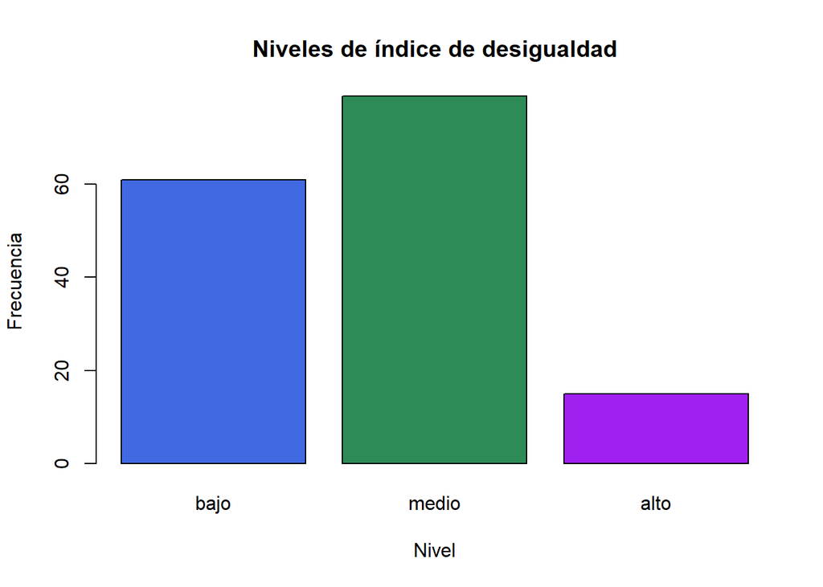

```r
plot(x = Base_de_datos$desigualdadord, main = "Niveles de índice de desigualdad",
     xlab = "Nivel", ylab = "Frecuencia",
     col = c("royalblue", "seagreen", "purple", "red"))
```

b.Variable independiente: índice de desarrollo humano

-Moda:

A partir de los datos demostrados podemos señalar que la mayoría de los países han presentado un nivel de índice de desarrollo medio ( es decir, la mayor parte de los países presentan índices de entre 0.4 a 0.8). Por el contrario, el nivel menos común entre los países evaluados de índice de desarrollo humano es el bajo.

```r
library(dplyr)

Base_de_datos$desarrolloord= cut(Base_de_datos$`Desarrollo humano`, breaks = c(0, 0.4, 0.8, 1), include.lowest = T, ordered_result = T, labels = c("bajo", "medio", "alto"))

table(Base_de_datos$desarrolloord)
```

```
##
##  bajo medio  alto
##     3   122    47
```

-Gráfico

A partir del presente gráfico podemos visualizar lo que hemos mencionado con anterioridad. Por un lado, la mayor proporción de países se encuentran en un nivel medio de índice de desarrollo humano, mientra que la minoría de ellos han presentado un índice bajo de desarollo.

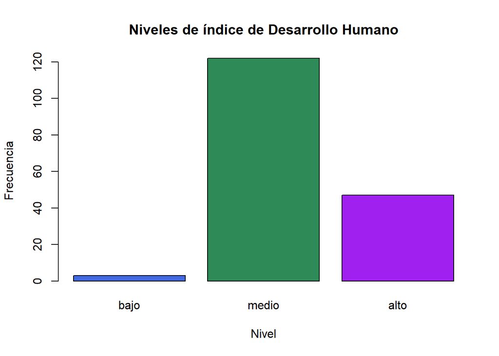

```r
plot(x = Base_de_datos$desarrolloord, main = "Niveles de índice de Desarrollo Humano",
     xlab = "Nivel", ylab = "Frecuencia",
     col = c("royalblue", "seagreen", "purple", "red"))
```

c.Variable independiente: inestabilidad política (escala del 1 al 5: valores más altos implica mayor inestabilidad)

-Moda: De manera general podemos señalar que la mayoría de países tienen “algo” de inestabilidad política. Asimismo, del total de la muestra sólo 9 países pueden ser catalogados con bastante inestabiidad política.

```r
library(dplyr)

Base_de_datos$Inestabilidadord= cut(Base_de_datos$Inestabilidad, breaks = c(0, 1, 2, 3, 4, 5), include.lowest = T, ordered_result = T, labels = c("muy poca", "poca", "algo", "regular", "bastante"))

table(Base_de_datos$Inestabilidadord)
```

```
##
## muy poca     poca     algo  regular bastante
##       17       44       56       36        9
```

-Gráfico Mediante este gráfico podemos confirmar lo mencionado anteriormente, el nivel de inestabilidad política más común entre los países es el de “algo” y el menos común es el de “bastante” (el nivel más alto).

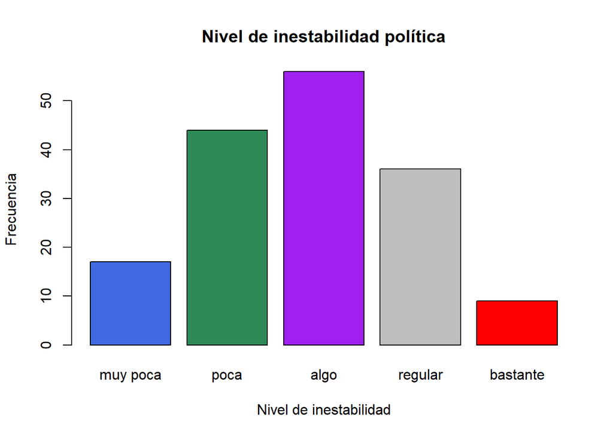

```r
plot(x = Base_de_datos$Inestabilidadord, main = "Nivel de inestabilidad política",
     xlab = "Nivel de inestabilidad", ylab = "Frecuencia",
     col = c("royalblue", "seagreen", "purple", "grey", "red"))
```

d.Variable independiente: tipo de régimen (autocracia pura, autocracia inclusiva, autocracia liberal, democracia mínima)

-Moda:

A partir de los resultados se puede observar que el tipo de regimen más común es el de democracia mínima, asimismo encontramos 60 países con autoritarismos puros y el tipo menos común es el de autocracia inclusiva.

```r
str(Base_de_datos$Regimen)
```

```
##  num [1:176] 1 4 1 1 4 1 4 4 1 4 ...
```

```r
Base_de_datos$Regimen= factor(Base_de_datos$Regimen, labels = c("pura", "inclusiva", "liberal", "minima"))

table(Base_de_datos$Regimen)
```

```
##
##      pura inclusiva   liberal    minima
##        60         6        12        90
```

-Gráfico

Como se puede observar, los dos regímenes más comunes son los de autocracias puras y democracias mínimas, mientras que el menos usual es el de autocracia inclusiva con solo 6 países.

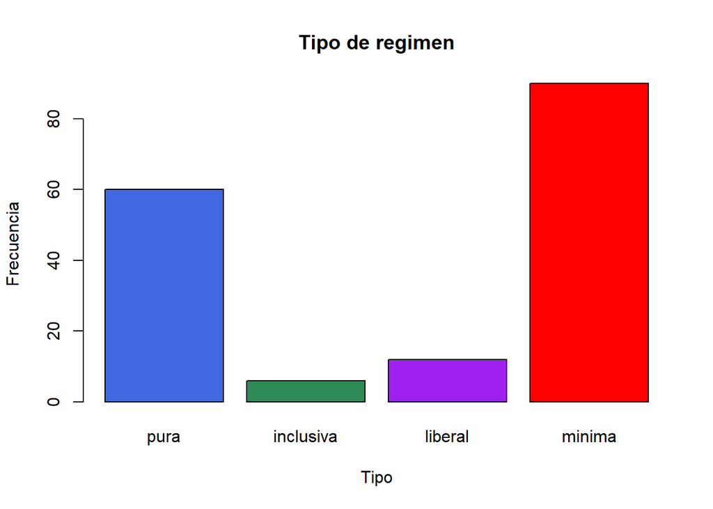

```r
plot(x = Base_de_datos$Regimen, main = "Tipo de regimen",
     xlab = "Tipo", ylab = "Frecuencia",
     col = c("royalblue", "seagreen", "purple", "red"))
```

6. Prueba:

   Para el presente trabajo proponemos utilizar la prueba de regresión logísitica ordinal pues se adecúa al tipo de variable dependiente con la que se va a a trabajar: categórica ordinal, la cual tiene más de dos niveles (bajo-medio-alto) y va en un orden ascendente. Además de ello, nos va a permitir comprobar nuestra hipótesis relacionada al alto nivel de desigualdad de género según el tipo de régimen, el índice de desarrollo humano y la inestabilidad política. De esta manera, trabajar con un modelo logísitco ordinal será de gran utilidad al momento de predecir si realmente nuestras variables independientes afectan al nivel de desigualdad de género que presenta un país y así, poder observar bajo qué escenarios y contextos socio-políticos, la igualdad de género se ve más o menos perjudicada.
7. Bibliografía

Bibliografía: BBC Mundo (2016). Mariana Martinez: “Barómetro económico: la mujer y la desigualdad” http://news.bbc.co.uk/hi/spanish/business/barometro_economico/newsid_4754000/4754380.stm

Caprioli, M (2000). “Gendered Conflict.” Journal of Peace Research 37: 51–68. ——. “Gender Equality and State Aggression: The Impact of Domestic Gender Equality on State First Use of Force.” International Interactions 29, no. 3 (2003): 195–214.

HUDSON, V. M., BOWEN, D. L., & NIELSEN, P. L. (2020). The First Political Order: How Sex Shapes Governance and National Security Worldwide. Columbia University Press. http://www.jstor.org/stable/10.7312/huds19466

Mones, B (2004). “La inclusión de las mujeres y la igualdad de género: nuevos desafíos para la modernización del Estado” en IX Congreso Internacional del CLAD sobre la Reforma del Estado y de la Administración Pública, Madrid, España, 2 – 5 Nov. 2004 http://americalatinagenera.org/newsite/images/cdr-documents/publicaciones/doc_444_0050134.pdf

Mukhopadhyay, M (2007). Justicia de género, ciudadanía y desarrollo. Centro Internacional de Investigaciones para el desarrollo. Tercera Edición, India, New Delhi. https://idl-bnc-idrc.dspacedirect.org/handle/10625/34957

Sahui, M (2015). La igualdad en la medida de la calidad democrática - Una revisión crítica de la propuesta de Leonardo Morlino. Revista Dossier - 7 de mayo de 2015: pp. 33 - 55 https://www.redalyc.org/pdf/421/42146505010.pdf

The WomanStatsProject (2019). Base de Datos sobre la situación de la mujer 2019. Brigham Young College, Utah. Revisado: 21 de agosto 2021 https://www.womanstats.org/new/

Wood, Reed, and Mark Ramirez (2018). “Exploring the Microfoundations of the Gender Equality Peace Hypothesis.” International Studies Review 20, no. 3: 345–367. https://doi.org /10.1093/isr/vix016.

World Economic Forum (2020). Global Gender Gap Report : “Informe Final de la brecha de desigualdad de género en el mundo 2020”. Revisado: 3 de setiembre 2021 https://www.weforum.org/reports/gender-gap-2020-report-100-years-pay-equality